# Introductory Statistics with Randomization and Simulation: Chapter 6

## Introduction to Multiple Regression

## Multiple Regression

- Simple linear regression: Bivariate, two variables: \(y\) and \(x\)
- Multiple linear regression: Multiple variables: \(y\) and \(x_1\), \(x_2\), \(\cdots\)

## Example: Weights of Books

[figure not shown]

```
##
##
##  volume   area   weight  cover
## -------  -----  -------  ------
##     885    382      800  hb
##    1016    468      950  hb
##    1125    387     1050  hb
##     239    371      350  hb
##     701    371      750  hb
##     641    367      600  hb
##    1228    396     1075  hb
##     412      0      250  pb
##     953      0      700  pb
##     929      0      650  pb
```

{From: Maindonald, J.H. and Braun, W.J. (2nd ed., 2007) "Data Analysis and Graphics Using R"

## Weight of Books (ctd.)

The scatterplot shows the relationship between weights and volumes of books, as well as the regression output. Which of the below is correct?

1. Weights of 80% of the books can be predicted accurately using this model.
2. Books that are 10 cm\(^3\) over average are expected to weigh 7g over average.
3. The correlation between weight and volume is R = 0.80\(^2\) = 0.64 .
4. The model underestimates the weight of the book with the highest volume.

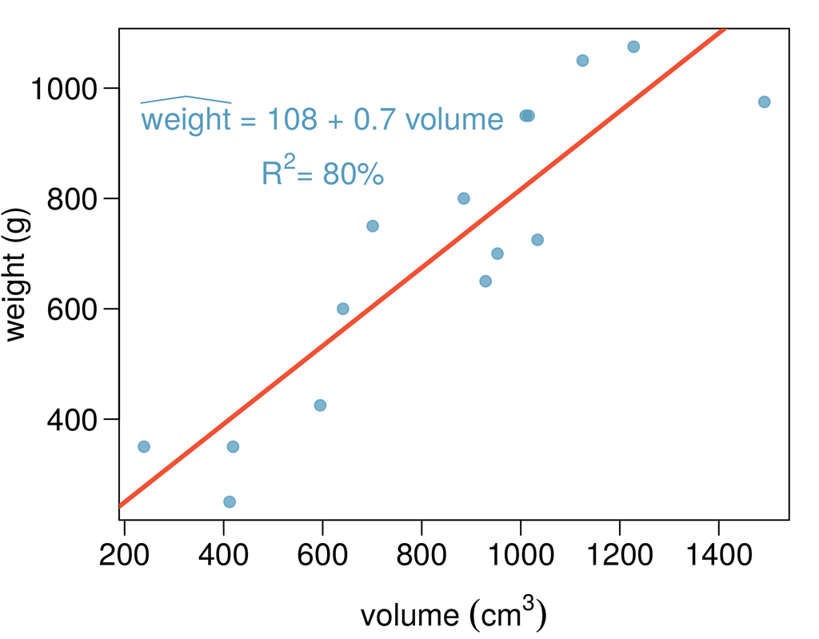

## Weight of Books (ctd.)

The scatterplot shows the relationship between weights and volumes of books, as well as the regression output. Which of the below is correct?

1. Weights of 80% of the books can be predicted accurately using this model.
2. Books that are 10 cm\(^3\) over average are expected to weigh 7g over average.
3. The correlation between weight and volume is R = 0.80\(^2\) = 0.64 .
4. The model underestimates the weight of the book with the highest volume.

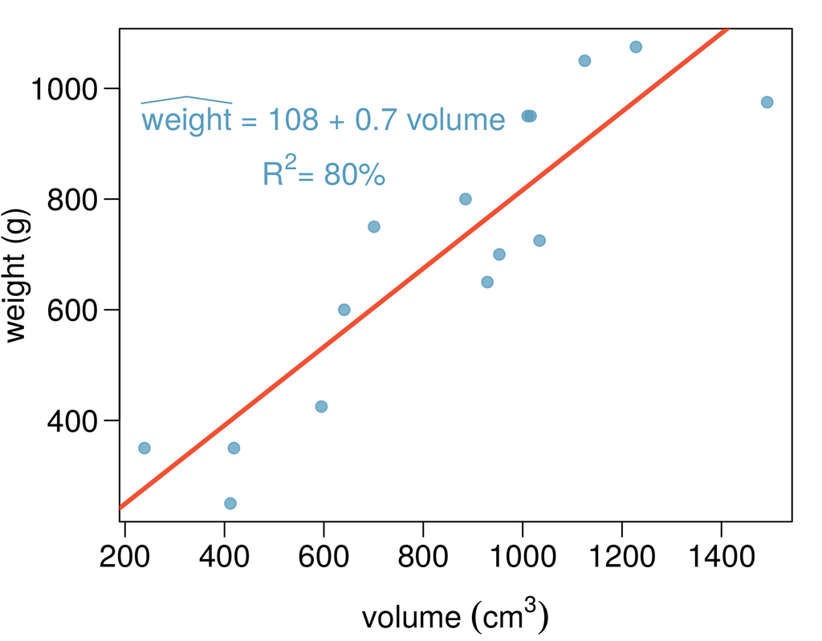

## Modeling weights of books using volume

```r
data(allbacks)
fit <- summary( lm(weight ~ volume, data = allbacks) )
```

```
Coefficients:
             Estimate Std. Error t value Pr(>|t|)
(Intercept) 107.67931   88.37758   1.218    0.245
volume        0.70864    0.09746   7.271 6.26e-06

Residual standard error: 123.9 on 13 degrees of freedom
Multiple R-squared: 0.8026,Adjusted R-squared: 0.7875
F-statistic: 52.87 on 1 and 13 DF, p-value: 6.262e-06
```

## Weights of hardcover and paperback books

Can you identify a trend in the relationship between volume and weight of hardcover and paperback books?

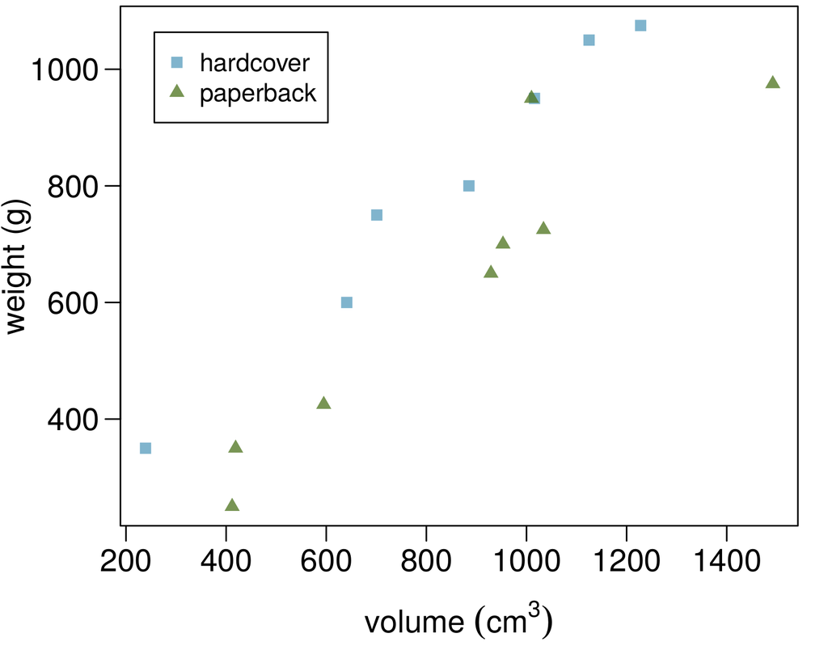

## Weights of hardcover and paperback books

Can you identify a trend in the relationship between volume and weight of hardcover and paperback books?

Paperbacks generally weigh less than hardcovers, after controlling for the book's volume.

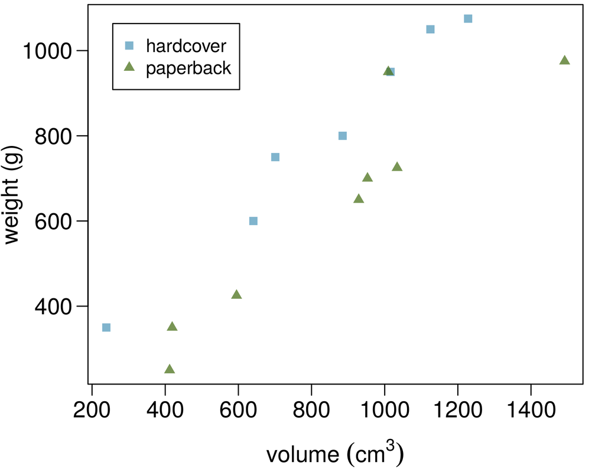

## Modeling weights of books using volume **and** cover type

```r
data(allbacks)
fit <- summary( lm(weight ~ volume + cover, data = allbacks) )
```

```
Coefficients:
              Estimate Std. Error t value Pr(>|t|)
(Intercept)  197.96284   59.19274   3.344 0.005841 **
volume         0.71795    0.06153  11.669  6.6e-08 ***
coverpb     -184.04727   40.49420  -4.545 0.000672 ***

Residual standard error: 78.2 on 12 degrees of freedom
Multiple R-squared:  0.9275,    Adjusted R-squared:  0.9154
F-statistic: 76.73 on 2 and 12 DF,  p-value: 1.455e-07
```

## Determining the reference level

Based on the regression output below, which level of \(\texttt{cover}\) is the reference level? Note that \(\texttt{pb}\) is paperback.

```
              Estimate Std. Error t value Pr(>|t|)
(Intercept)  197.96284   59.19274   3.344 0.005841 **
volume         0.71795    0.06153  11.669  6.6e-08 ***
coverpb     -184.04727   40.49420  -4.545 0.000672 ***
```

1. paperback
2. hardcover

## Determining the reference level

Based on the regression output below, which level of \(\texttt{cover}\) is the reference level? Note that \(\texttt{pb}\) is paperback.

```
              Estimate Std. Error t value Pr(>|t|)
(Intercept)  197.96284   59.19274   3.344 0.005841
volume         0.71795    0.06153  11.669  6.6e-08
coverpb     -184.04727   40.49420  -4.545 0.000672
```

1. paperback
2. hardcover

## Determining the reference level

Which of the below correctly describes the roles of variables in this regression model?

```
              Estimate Std. Error t value Pr(>|t|)
(Intercept)  197.96284   59.19274   3.344 0.005841
volume         0.71795    0.06153  11.669  6.6e-08
coverpb     -184.04727   40.49420  -4.545 0.000672
```

1. response: weight, explanatory: volume, paperback cover
2. response: weight, explanatory: volume, hardcover cover
3. response: volume, explanatory: weight, cover type
4. response: weight, explanatory: volume, cover type

## Determining the reference level

Which of the below correctly describes the roles of variables in this regression model?

```
              Estimate Std. Error t value Pr(>|t|)
(Intercept)  197.96284   59.19274   3.344 0.005841
volume         0.71795    0.06153  11.669  6.6e-08
coverpb     -184.04727   40.49420  -4.545 0.000672
```

1. response: weight, explanatory: volume, paperback cover
2. response: weight, explanatory: volume, hardcover cover
3. response: volume, explanatory: weight, cover type
4. response: weight, explanatory: volume, cover type

## Linear Model

```
              Estimate Std. Error t value Pr(>|t|)
(Intercept)  197.96284   59.19274   3.344 0.005841
volume         0.71795    0.06153  11.669  6.6e-08
coverpb     -184.04727   40.49420  -4.545 0.000672
```

\[ \hat{\text{weight}} = 197.96 + 0.72 \cdot \text{volume} - 184.05 \cdot \text{coverpb} \]

## Linear Model

```
              Estimate Std. Error t value Pr(>|t|)
(Intercept)  197.96284   59.19274   3.344 0.005841
volume         0.71795    0.06153  11.669  6.6e-08
coverpb     -184.04727   40.49420  -4.545 0.000672
```

\[ \hat{\text{weight}} = 197.96 + 0.72 \cdot \text{volume} - 184.05 \cdot \text{coverpb} \]

1. For hardcover books, plug in **0** for \(\texttt{cover}\)

   \[ \begin{split} \hat{\text{weight}} &= 197.96 + 0.72 \cdot \text{volume} - 184.05 \cdot 0 \\ \end{split} \]

## Linear Model

```
              Estimate Std. Error t value Pr(>|t|)
(Intercept)  197.96284   59.19274   3.344 0.005841
volume         0.71795    0.06153  11.669  6.6e-08
coverpb     -184.04727   40.49420  -4.545 0.000672
```

\[ \hat{\text{weight}} = 197.96 + 0.72 \cdot \text{volume} - 184.05 \cdot \text{coverpb} \]

1. For hardcover books, plug in **0** for \(\texttt{cover}\)

   \[ \begin{split} \hat{\text{weight}} &= 197.96 + 0.72 \cdot \text{volume} - 184.05 \cdot 0 \\ &= 197.96 + 0.72 \cdot \text{volume} \end{split} \]

## Linear Model

```
              Estimate Std. Error t value Pr(>|t|)
(Intercept)  197.96284   59.19274   3.344 0.005841
volume         0.71795    0.06153  11.669  6.6e-08
coverpb     -184.04727   40.49420  -4.545 0.000672
```

\[ \hat{\text{weight}} = 197.96 + 0.72 \cdot \text{volume} - 184.05 \cdot \text{coverpb} \]

1. For hardcover books, plug in **0** for \(\texttt{cover}\)

   \[ \begin{split} \hat{\text{weight}} &= 197.96 + 0.72 \cdot \text{volume} - 184.05 \cdot 0 \\ &= 197.96 + 0.72 \cdot \text{volume} \end{split} \]
2. For paperback books, plug in **1** for \(\texttt{cover}\)

   \[ \begin{split} \hat{\text{weight}} &= 197.96 + 0.72 \cdot \text{volume} - 184.05 \cdot 1 \\ \end{split} \]

## Linear Model

```
              Estimate Std. Error t value Pr(>|t|)
(Intercept)  197.96284   59.19274   3.344 0.005841
volume         0.71795    0.06153  11.669  6.6e-08
coverpb     -184.04727   40.49420  -4.545 0.000672
```

\[ \hat{\text{weight}} = 197.96 + 0.72 \cdot \text{volume} - 184.05 \cdot \text{coverpb} \]

1. For hardcover books, plug in **0** for \(\texttt{cover}\)

   \[ \begin{split} \hat{\text{weight}} &= 197.96 + 0.72 \cdot \text{volume} - 184.05 \cdot 0 \\ &= 197.96 + 0.72 \cdot \text{volume} \end{split} \]
2. For paperback books, plug in **1** for \(\texttt{cover}\)

   \[ \begin{split} \hat{\text{weight}} &= 197.96 + 0.72 \cdot \text{volume} - 184.05 \cdot 1 \\ &= 13.91 + 0.72 \cdot \text{volume} \end{split} \]

## Visualizing the linear model

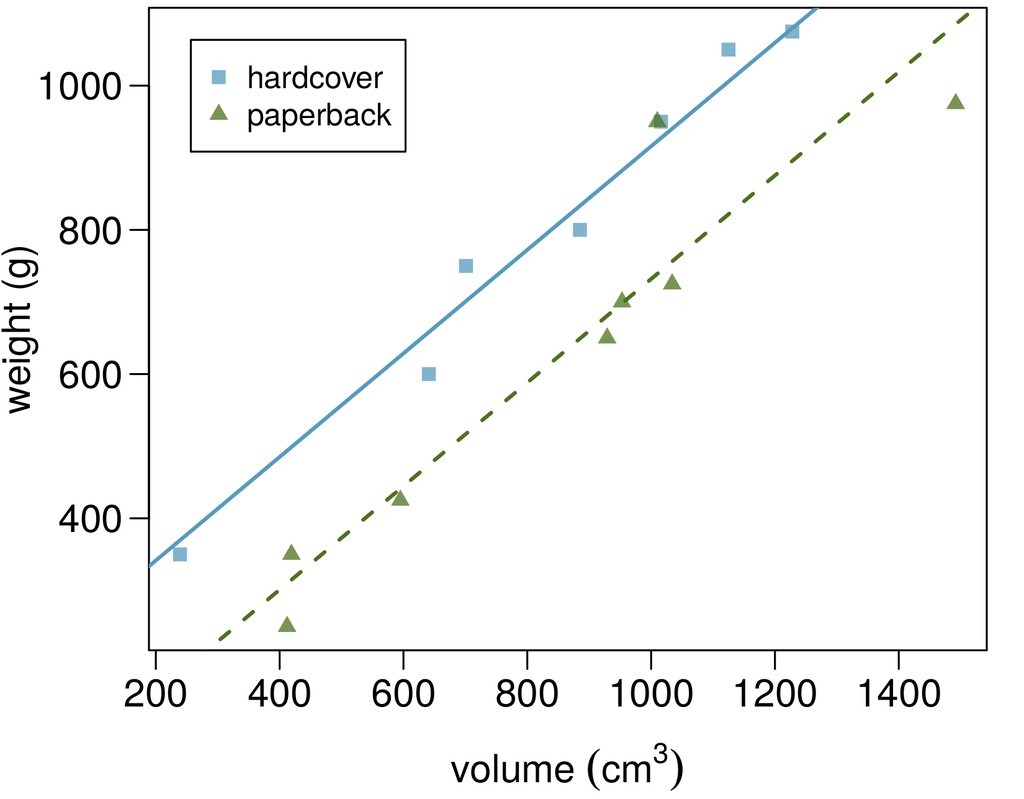

## Interpretation of the regression coefficients

```
              Estimate Std. Error t value Pr(>|t|)
(Intercept)  197.96284   59.19274   3.344 0.005841
volume         0.71795    0.06153  11.669  6.6e-08
coverpb     -184.04727   40.49420  -4.545 0.000672
```

## Interpretation of the regression coefficients

```
              Estimate Std. Error t value Pr(>|t|)
(Intercept)  197.96284   59.19274   3.344 0.005841
volume         0.71795    0.06153  11.669  6.6e-08
coverpb     -184.04727   40.49420  -4.545 0.000672
```

- Slope of volume: All else held constant, books that are 1 more cubic centimeter in volume tend to weigh about 0.72 grams more.

## Interpretation of the regression coefficients

```
              Estimate Std. Error t value Pr(>|t|)
(Intercept)  197.96284   59.19274   3.344 0.005841
volume         0.71795    0.06153  11.669  6.6e-08
coverpb     -184.04727   40.49420  -4.545 0.000672
```

- Slope of volume: All else held constant, books that are 1 more cubic centimeter in volume tend to weigh about 0.72 grams more.
- Slope of cover: All else held constant, the model predicts that paperback books weigh 184 grams lower than hardcover books.

## Interpretation of the regression coefficients

```
              Estimate Std. Error t value Pr(>|t|)
(Intercept)  197.96284   59.19274   3.344 0.005841
volume         0.71795    0.06153  11.669  6.6e-08
coverpb     -184.04727   40.49420  -4.545 0.000672
```

- Slope of volume: All else held constant, books that are 1 more cubic centimeter in volume tend to weigh about 0.72 grams more.
- Slope of cover: All else held constant, the model predicts that paperback books weigh 184 grams lower than hardcover books.
- Intercept: Hardcover books with no volume are expected on average to weigh 198 grams.

## Interpretation of the regression coefficients

```
              Estimate Std. Error t value Pr(>|t|)
(Intercept)  197.96284   59.19274   3.344 0.005841
volume         0.71795    0.06153  11.669  6.6e-08
coverpb     -184.04727   40.49420  -4.545 0.000672
```

- Slope of volume: All else held constant, books that are 1 more cubic centimeter in volume tend to weigh about 0.72 grams more.
- Slope of cover: All else held constant, the model predicts that paperback books weigh 184 grams lower than hardcover books.
- Intercept: Hardcover books with no volume are expected on average to weigh 198 grams.
  - Obviously, the intercept does not make sense in context. It only serves to adjust the height of the line.

## Prediction

Which of the following is the correct calculation for the predicted weight of a paperback book that is 600 cm\(^3\)?

```
              Estimate Std. Error t value Pr(>|t|)
(Intercept)  197.96284   59.19274   3.344 0.005841
volume         0.71795    0.06153  11.669  6.6e-08
coverpb     -184.04727   40.49420  -4.545 0.000672
```

1. 197.96 + 0.72 * 600 - 184.05 * 1
2. 184.05 + 0.72 * 600 - 197.96 * 1
3. 197.96 + 0.72 * 600 - 184.05 * 0
4. 197.96 + 0.72 * 1 - 184.05 * 600

## Prediction

Which of the following is the correct calculation for the predicted weight of a paperback book that is 600 cm\(^3\)?

```
              Estimate Std. Error t value Pr(>|t|)
(Intercept)  197.96284   59.19274   3.344 0.005841
volume         0.71795    0.06153  11.669  6.6e-08
coverpb     -184.04727   40.49420  -4.545 0.000672
```

1. 197.96 + 0.72 * 600 - 184.05 * 1
2. 184.05 + 0.72 * 600 - 197.96 * 1
3. 197.96 + 0.72 * 600 - 184.05 * 0
4. 197.96 + 0.72 * 1 - 184.05 * 600

## Another example: Modeling children's test scores

Predicting cognitive test scores of three- and four-year-old children using characteristics of their mothers. Data are from a survey of adult American women and their children - a subsample from the National Longitudinal Survey of Youth.

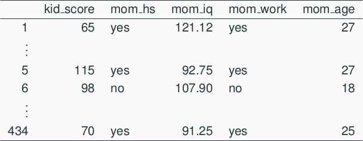

Gelman & Hill. Data Analysis Using Regression and Multilevel/Hierarchical Models. (2007) Cambridge University Press.

## Interpretation

All else being equal, kids whose moms worked during the first three years of the kids life:

## Interpretation

All else being equal, kids whose moms worked during the first three years of the kids life:

## Revisit: Modeling poverty

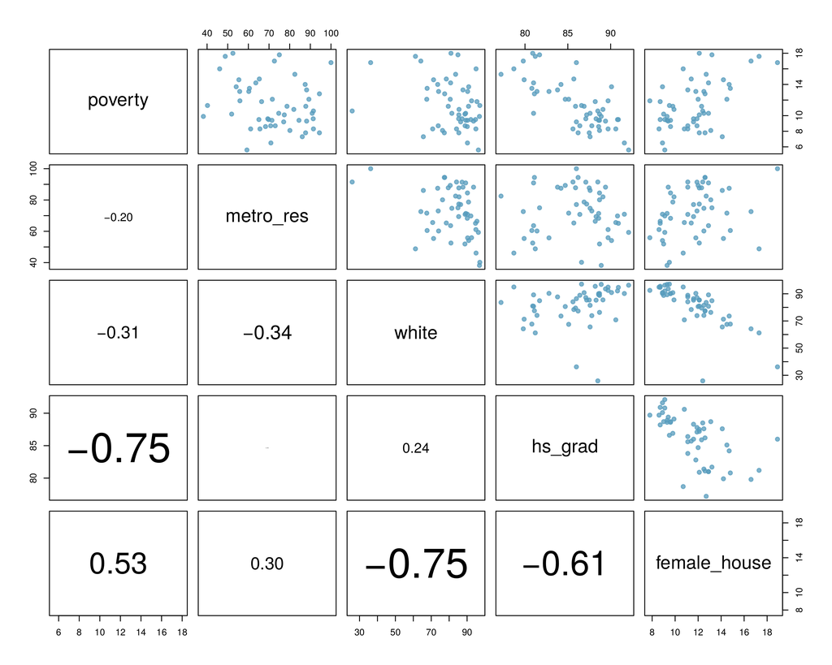

## Revisit: Modeling poverty

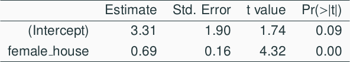

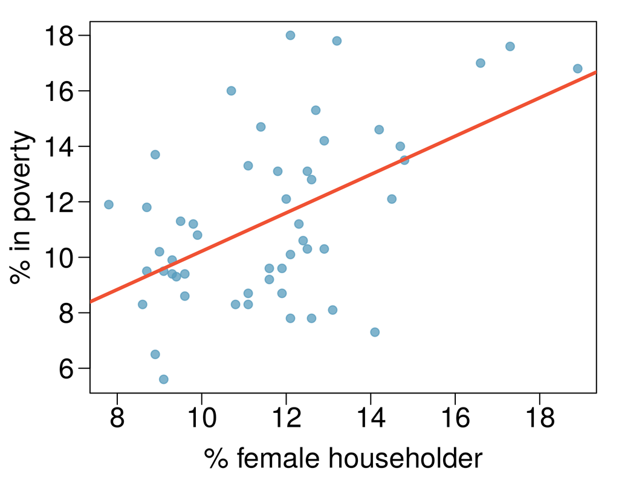

\[ \begin{split} R &= 0.53 \\ R^2 &= 0.53^2 = 0.28 \end{split} \]

## Another look at \(R^2\)

\(R^2\) can be calculated in three ways:

## Another look at \(R^2\)

\(R^2\) can be calculated in three ways:

1. square the correlation coefficient of \(x\) and \(y\) (how we have been calculating it)

## Another look at \(R^2\)

\(R^2\) can be calculated in three ways:

1. square the correlation coefficient of \(x\) and \(y\) (how we have been calculating it)
2. square the correlation coefficient of \(y\) and \(\hat{y}\)

## Another look at \(R^2\)

\(R^2\) can be calculated in three ways:

1. square the correlation coefficient of \(x\) and \(y\) (how we have been calculating it)
2. square the correlation coefficient of \(y\) and \(\hat{y}\)
3. based on definition:

   \[ R^2 = \frac{\text{explained variability in $y$}}{\text{total variability in $y$}} \]